# Assignment - Week 05

Flurin Schindele

2026-03-24

```r
suppressPackageStartupMessages({
  library(GenomicRanges)
  library(SummarizedExperiment)
  library(edgeR) # differential gene expression using neg.bin stats
  library(epiwraps)
  library(ggplot2)
  library(sechm) # for plotting (features*samples) heatmaps
  library(dplyr)
})
dir.create("./data", showWarnings = FALSE)
download.file(
  "https://ethz-ins.org/content/mouse_mm38_hippocampus.peakCounts.SE.rds",
  "data/mm38-hippocampus-peaksCounts.rds",
  mode="wb"
)
```

We are working with ATAC-seq data from the hippocampus of mice. As data we have raw peak counts. FSS denotes the “forced swim stress” condition.

```r
se <- readRDS("data/mm38-hippocampus-peaksCounts.rds")
print(se)
```

```
## class: RangedSummarizedExperiment
## dim: 20660 12
## metadata(0):
## assays(1): counts
## rownames: NULL
## rowData names(0):
## colnames(12): Control_female_GSM6041841.bam
##   Control_female_GSM6041842.bam ... FSS_male_GSM6041857.bam
##   FSS_male_GSM6041858.bam
## colData names(1): depth
```

```r
print(colData(se))
```

```
## DataFrame with 12 rows and 1 column
##                                   depth
##                               <numeric>
## Control_female_GSM6041841.bam  73170149
## Control_female_GSM6041842.bam  93995034
## Control_female_GSM6041843.bam  40167775
## Control_male_GSM6041844.bam    70491005
## Control_male_GSM6041845.bam    84985977
## ...                                 ...
## FSS_female_GSM6041854.bam      73674456
## FSS_female_GSM6041855.bam      49285912
## FSS_male_GSM6041856.bam        82385764
## FSS_male_GSM6041857.bam        68623011
## FSS_male_GSM6041858.bam        81801232
```

First, we need to assign labels to the samples. As we want to compare stressed (FSS) and control samples as well as male and female mice, we need to distinguish both groups.

```r
colData(se)$condition <- ifelse(grepl("FSS", row.names(colData(se))), "FSS", "Control")
colData(se)$sex <- ifelse(grepl("_male_", row.names(colData(se))), "male", "female")
print(colData(se))
```

```
## DataFrame with 12 rows and 3 columns
##                                   depth   condition         sex
##                               <numeric> <character> <character>
## Control_female_GSM6041841.bam  73170149     Control      female
## Control_female_GSM6041842.bam  93995034     Control      female
## Control_female_GSM6041843.bam  40167775     Control      female
## Control_male_GSM6041844.bam    70491005     Control        male
## Control_male_GSM6041845.bam    84985977     Control        male
## ...                                 ...         ...         ...
## FSS_female_GSM6041854.bam      73674456         FSS      female
## FSS_female_GSM6041855.bam      49285912         FSS      female
## FSS_male_GSM6041856.bam        82385764         FSS        male
## FSS_male_GSM6041857.bam        68623011         FSS        male
## FSS_male_GSM6041858.bam        81801232         FSS        male
```

We also need to assign row names to the assay.

```r
rownames(se) <- as.character(rowRanges(se))
head(rownames(se))
```

```
## [1] "1:3012609-3012858" "1:3094941-3095190" "1:3113634-3113883"
## [4] "1:3119522-3119771" "1:3119880-3120129" "1:3120379-3120628"
```

# 1. Comparing Sex

For the first analysis, we will focus on the sex differences in chromatin accessibility in the murine hippocampus. We will be using edgeR for differential analysis.

1. Normalization is done using the TMM method, which should correct for sequencing depth differences between samples and the composition bias.
2. We estimate dispersion in order to correctly model the count data as a negative binomial distribution. The BCV plot can give us some insight into how well this worked.
3. We then perform an exact test to identify differentially accessible regions between male and female mice.

```r
# Put data into format required by edgeR
dds_sex<- edgeR::DGEList(assay(se), group=se$sex)

# Normalization with TMM
dds_sex <- edgeR::calcNormFactors(dds_sex)
assay(se, "logcpm_sex") <- log1p(edgeR::cpm(dds_sex))

# Dispersion estimation
dds_sex <- edgeR::estimateDisp(dds_sex)
```

```
## Using classic mode.
```

```r
et_sex <- as.data.frame(topTags(exactTest(dds_sex), Inf))
et_sex %>%
  filter(FDR <= 0.05) %>%
  head(10)
```

```
##                         logFC   logCPM       PValue          FDR
## Y:1010447-1010696    6.876619 6.682547 2.920875e-22 6.034527e-18
## Y:1010170-1010419    6.864394 6.813826 3.240455e-19 3.347390e-15
## Y:809076-809325      6.419731 5.522297 7.380964e-19 5.083024e-15
## Y:1245354-1245603    6.184489 5.260409 4.044926e-17 2.089204e-13
## Y:897407-897656      8.759947 4.548791 6.643063e-17 2.744914e-13
## Y:1245678-1245927    7.175640 6.896536 9.138607e-17 2.984284e-13
## X:50591034-50591283 -5.905083 5.983284 1.011132e-16 2.984284e-13
## X:50583794-50584043 -5.473241 6.233290 1.249591e-16 3.031335e-13
## Y:1286466-1286715    7.629468 6.982274 1.320524e-16 3.031335e-13
## X:50590734-50590983 -5.172471 6.575802 1.783858e-16 3.355204e-13
```

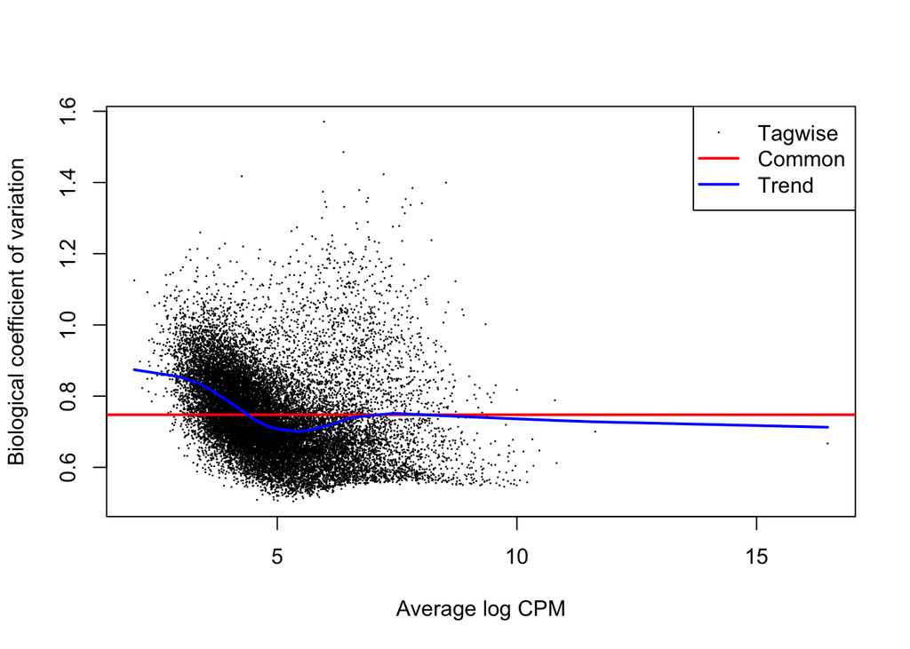

```r
plotBCV(dds_sex)
```

The plot shows us that the biological coefficient of variation (BCV) is relatively high. Apparently, the blue line should also decrease with increasing CPM which is not really the case here. **Question, ask in lecture…**

The table above shows us that the top hits are all located on either the Y or X chromosome. This should not be surprising for anyone but does not really help us in the analysis. Maybe this could also influence dispersion estimation.

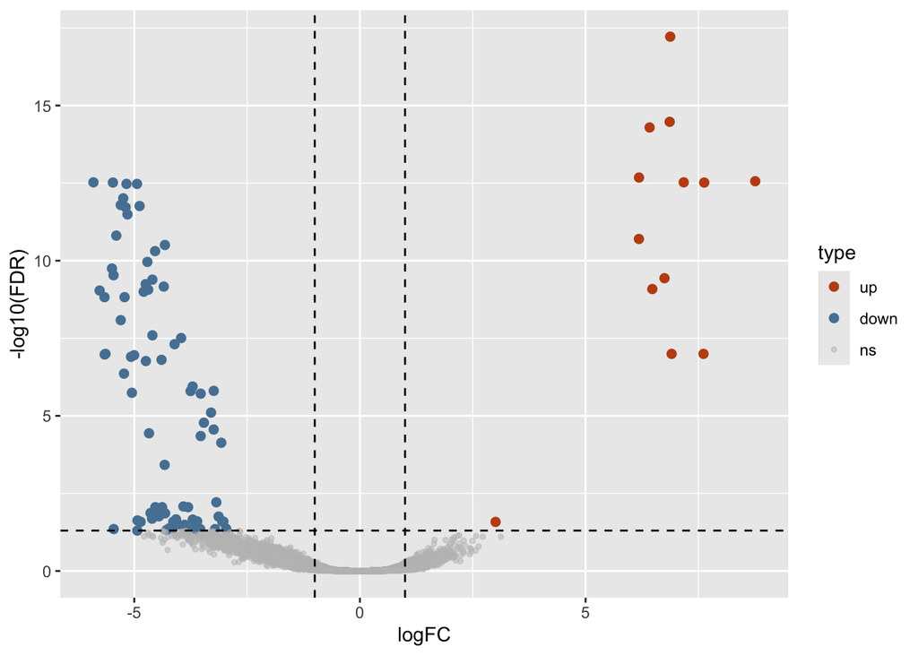

```r
colors <- c("up" = "#C04F15", "down" = "#5682A3", "ns" = "grey")
sizes <- c("up" = 2, "down" = 2, "ns" = 1)
alphas <- c("up" = 1, "down" = 1, "ns" = 0.5)

et_sex <- et_sex %>%
  mutate(type = case_when(
    logFC >= 1 & FDR <= 0.05 ~ "up",
    logFC <= -1 & FDR <= 0.05 ~ "down",
    TRUE ~ "ns"
    )
)

et_sex$type <- factor(et_sex$type, levels=c("up", "down", "ns"))

ggplot(data = et_sex,
       aes(x = logFC,
           y = -log10(FDR))) +
  geom_point(aes(color = type,
                 size = type,
                 alpha = type)) +
  geom_hline(yintercept = -log10(0.05),
             linetype = "dashed") +
  geom_vline(xintercept = c(log2(0.5), log2(2)),
             linetype = "dashed") +
  scale_colour_manual(values = colors) +
  scale_size_manual(values = sizes) +
  scale_alpha_manual(values = alphas)
```

We can look further into the count data of the top hits. This could show us outliers and should also confirm the sex-chromosome problem.

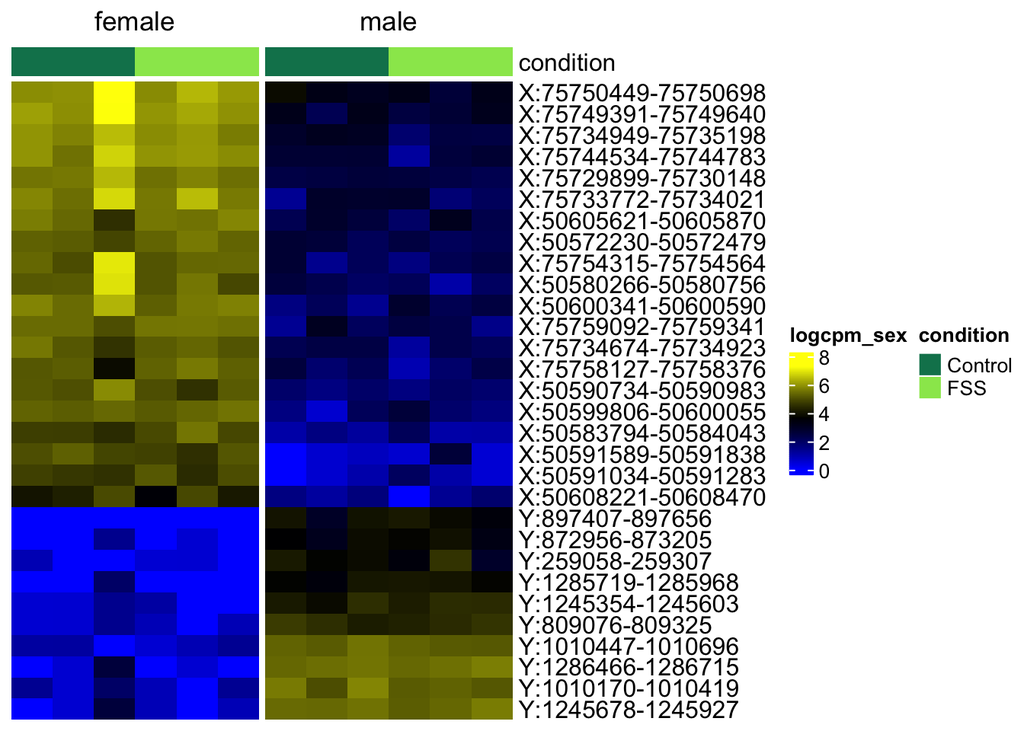

```r
topRegions_sex <- head(row.names(et_sex), 30)
sechm(se, topRegions_sex, gaps_at="sex", assayName = "logcpm_sex")
```

**Question: What does the do.scale parameter do?**

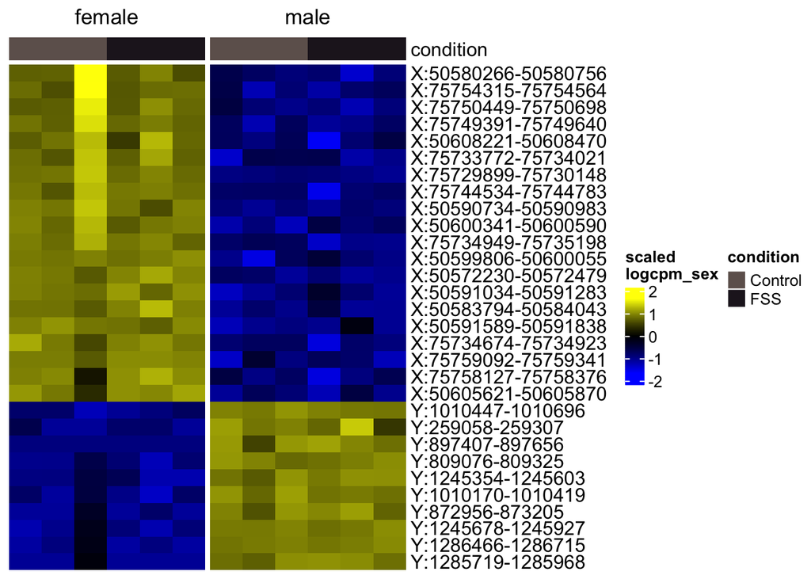

```r
sechm(se, topRegions_sex, gaps_at="sex", assayName = "logcpm_sex", do.scale = TRUE)
```

## Filtering out sex chromosomes

By filtering out the sex chromosomes, we can increase the statistical power of our analysis to detect differences on the autosomes.

```r
autosomes <- as.character(c(1:19))
se_autosomes <- se[seqnames(se) %in% autosomes, ]

dds_autosomes<- edgeR::DGEList(assay(se_autosomes), group=se$sex)

# Normalization with TMM
dds_autosomes <- edgeR::calcNormFactors(dds_autosomes)
assay(se_autosomes, "logcpm_autosomes") <- log1p(edgeR::cpm(dds_autosomes))

# Dispersion estimation
dds_autosomes <- edgeR::estimateDisp(dds_autosomes)
```

```
## Using classic mode.
```

```r
et_autosomes <- as.data.frame(topTags(exactTest(dds_autosomes), Inf))
head(et_autosomes, 5)
```

```
##                           logFC   logCPM       PValue       FDR
## 1:24143397-24143646   -4.368338 5.816852 2.797778e-05 0.1189138
## 1:182055142-182055391 -4.508445 7.408549 3.045074e-05 0.1189138
## 1:83622322-83622571   -3.790363 5.979893 3.098684e-05 0.1189138
## 1:54734997-54735246   -4.294158 7.772570 4.962009e-05 0.1189138
## 1:30595510-30595759   -4.617940 7.650355 5.060064e-05 0.1189138
```

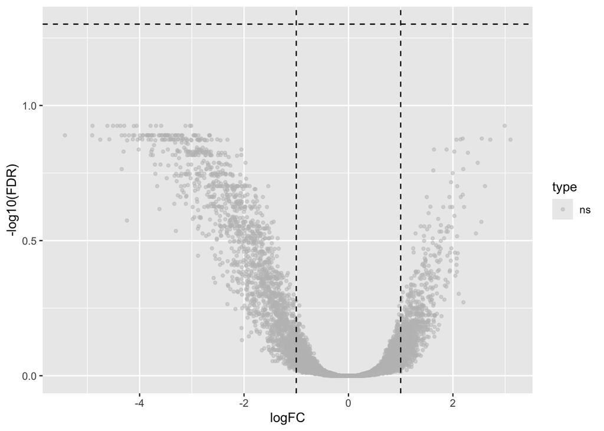

```r
et_autosomes <- et_autosomes %>%
  mutate(type = case_when(
    logFC >= 1 & FDR <= 0.05 ~ "up",
    logFC <= -1 & FDR <= 0.05 ~ "down",
    TRUE ~ "ns"
    )
)

et_autosomes$type <- factor(et_autosomes$type, levels=c("up", "down", "ns"))

ggplot(data = et_autosomes,
       aes(x = logFC,
           y = -log10(FDR))) +
  geom_point(aes(color = type,
                 size = type,
                 alpha = type)) +
  geom_hline(yintercept = -log10(0.05),
             linetype = "dashed") +
  geom_vline(xintercept = c(log2(0.5), log2(2)),
             linetype = "dashed") +
  scale_colour_manual(values = colors) +
  scale_size_manual(values = sizes) +
  scale_alpha_manual(values = alphas)
```

When filtering out the sex chromosomes, we see that there are no significant differences in chromatin accessibility between male and female mice.

# 2. Stressed (FSS) vs. Control

We can repeat the same procedure and compare stressed versus non-stressed mice.

```r
dds_cond <- edgeR::DGEList(assay(se), group=se$condition)
dds_cond <- edgeR::calcNormFactors(dds_cond)
assay(se, "logcpm_condition") <- log1p(edgeR::cpm(dds_cond))
dds_cond <- edgeR::estimateDisp(dds_cond)
```

```
## Using classic mode.
```

```r
et_cond <- as.data.frame(topTags(exactTest(dds_cond), Inf))
```

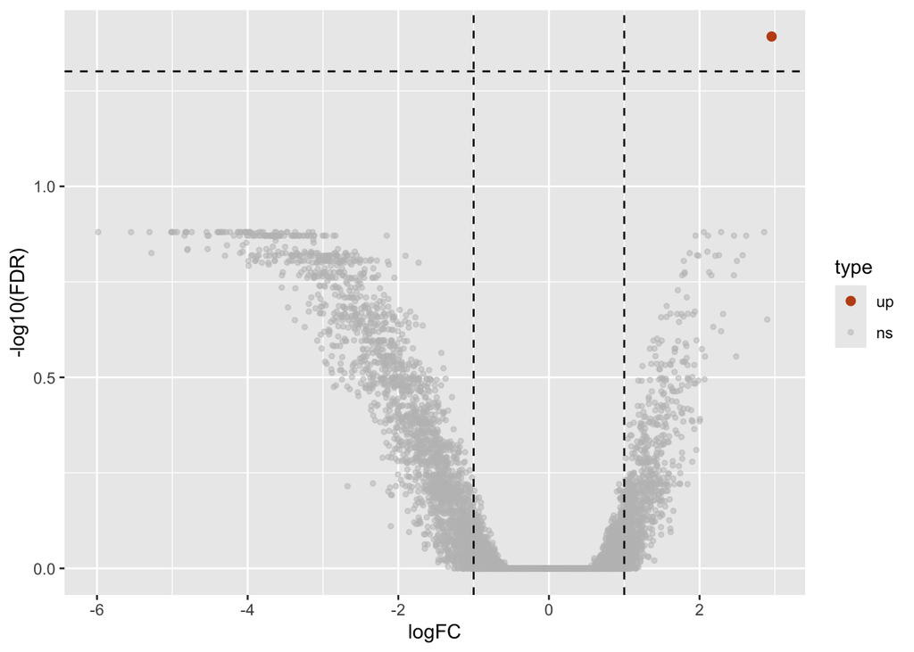

```r
et_cond <- et_cond %>%
  mutate(type = case_when(
    logFC >= 1 & FDR <= 0.05 ~ "up",
    logFC <= -1 & FDR <= 0.05 ~ "down",
    TRUE ~ "ns"
    )
)

et_cond$type <- factor(et_cond$type, levels=c("up", "down", "ns"))

ggplot(data = et_cond,
       aes(x = logFC,
           y = -log10(FDR))) +
  geom_point(aes(color = type,
                 size = type,
                 alpha = type)) +
  geom_hline(yintercept = -log10(0.05),
             linetype = "dashed") +
  geom_vline(xintercept = c(log2(0.5), log2(2)),
             linetype = "dashed") +
  scale_colour_manual(values = colors) +
  scale_size_manual(values = sizes) +
  scale_alpha_manual(values = alphas)
```

One region is significantly more accessible in stressed mice compared to controls.

```r
et_cond %>%
  filter(FDR <= 0.05)
```

```
##                         logFC   logCPM       PValue        FDR type
## 1:190561376-190561625 2.95648 5.568769 1.961625e-06 0.04052717   up
```

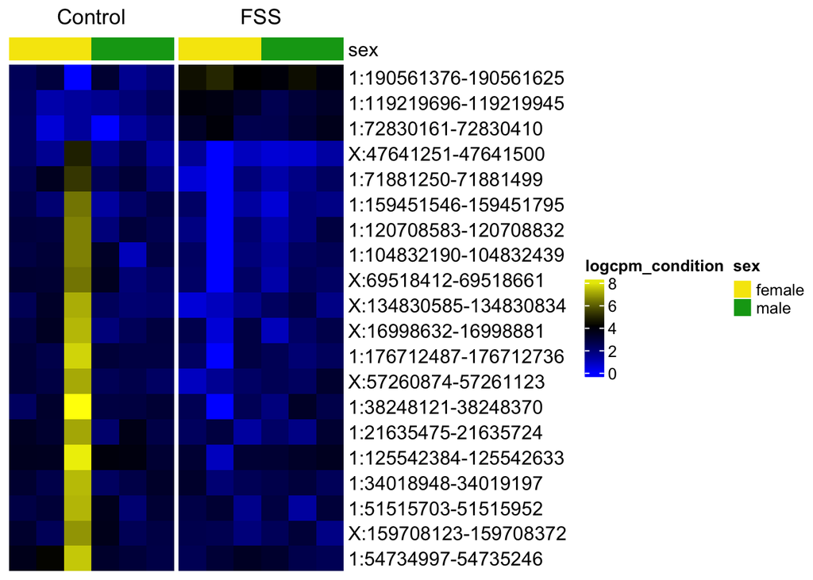

```r
topRegions_cond <- head(row.names(et_cond), 20)
sechm(se, topRegions_cond, gaps_at="condition", top_annotation="sex", anno_colors = list("gold", "darkred"), assayName = "logcpm_condition")
```

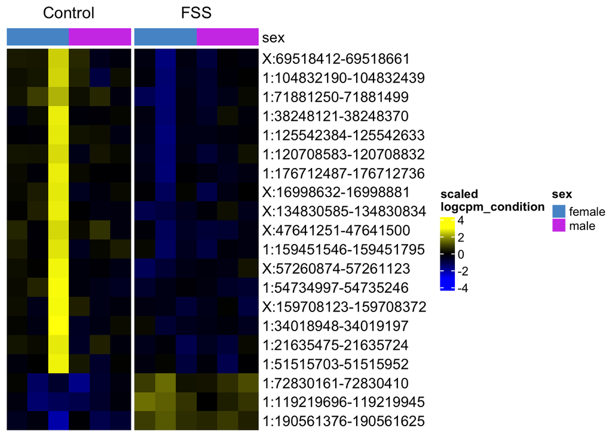

```r
# Question: why are anno_colors ignored?
sechm(se, topRegions_cond, gaps_at="condition", top_annotation="sex", anno_colors = list("gold", "darkred"), assayName = "logcpm_condition", do.scale = TRUE)
```

# Extra: Controlling for Sex

We should control for a potential confounding effect of the sex on the condition effect. For this we can use generalized linear models as described in [edgeR User’s Guide, section 2.12](https://www.bioconductor.org/packages/release/bioc/vignettes/edgeR/inst/doc/edgeRUsersGuide.pdf).

```r
# 1. Create design matrix
design <- model.matrix(~ sex + condition, data = colData(se))

# 2. Initialize DGEList and normalize
dge <- DGEList(counts = assay(se))
dge <- calcNormFactors(dge)
assay(se, "logcpm_sex_condition") <- log1p(edgeR::cpm(dge))

# 3. Estimate dispersion using the design matrix
dge <- estimateDisp(dge, design)

# 4. Fit the Quasi-Likelihood GLM (Recommended for better FDR control)
fit <- glmQLFit(dge, design)

# 5. Test for the 'condition' effect which is the last column in the design matrix
qlf <- glmQLFTest(fit, coef = ncol(design))

summary(decideTests(qlf))
```

```
##        conditionFSS
## Down              0
## NotSig        20660
## Up                0
```

```r
res <- as.data.frame(topTags(qlf, n = Inf))
head(res)
```

```
##                           logFC   logCPM        F       PValue       FDR
## 1:190561376-190561625  2.902687 5.569378 23.84297 0.0000552647 0.9995931
## 1:72830161-72830410    2.822642 4.138278 16.07731 0.0004578764 0.9995931
## 1:9851493-9851742      2.073670 5.877499 16.40954 0.0004709677 0.9995931
## X:19311392-19311641   -2.709344 5.380703 15.97857 0.0005226771 0.9995931
## X:47641251-47641500   -3.454265 3.757707 13.87984 0.0008227180 0.9995931
## X:57787670-57787919   -4.011548 5.949095 14.25110 0.0008406119 0.9995931
```

Sadly, we do not find any significant differences between stressed and control mice when controlling for the sex effect.

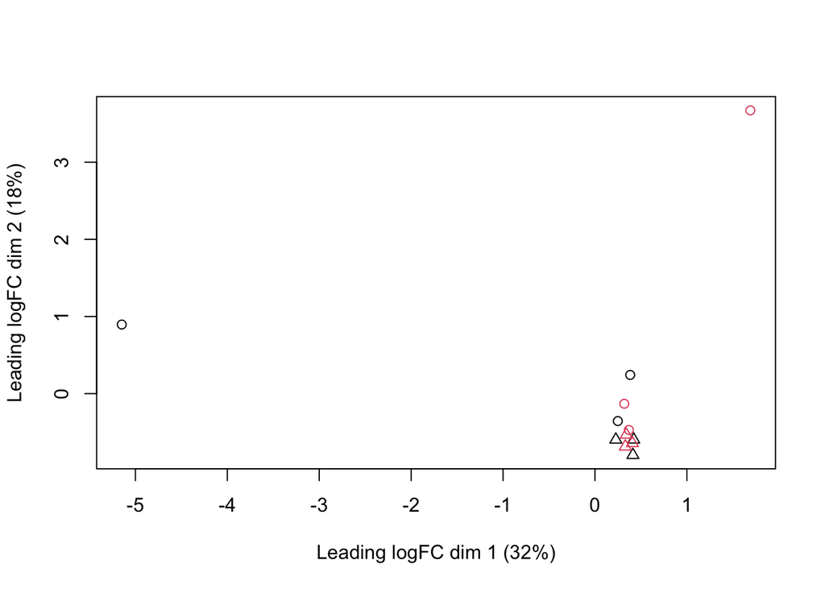

```r
# Create an MDS plot colored by condition and shaped by sex
plotMDS(dge, col = as.numeric(factor(se$condition)),
        pch = as.numeric(factor(se$sex)))
```

```r
#legend("topleft", legend = levels(factor(se$condition)),
#       text.col = 1:nlevels(factor(se$condition)))
```